# stringency

Things to explore:

- stringency index vs cases
- " vs R
- " vs positivity (?)
- specific measures vs cases/R/positivity

Data for specific measures: https://ourworldindata.org/policy-responses-covid

Different correlation statistics:

- Pearson: linear
- Spearman: monotonic

```python
%%capture
!pip install git+git://github.com/geopandas/geopandas.git
!apt install proj-bin libproj-dev libgeos-dev
!pip install git+git://github.com/ResidentMario/geoplot.git
!pip install pycountry
```

```python
import numpy as np
import matplotlib.pyplot as plt
import matplotlib.dates as mdates
import numpy.polynomial.polynomial as poly
import pandas as pd
from scipy.stats import pearsonr, spearmanr
import geopandas as gpd
import geoplot as gplt
import pycountry
from google.colab import drive
import os

# suppress warnings (bad practice, i know)
pd.options.mode.chained_assignment = None
```

```python
drive.mount('/content/drive')
os.chdir("drive/My Drive/Citadel Datathon 2021")
!ls
```

```
 1_owid		     Finance		   'Report draft.gdoc'
 2_ecdc		    '^FTSE.csv'		    Report.gdoc
 3_covidtracking    'GOV.UK Transport'	    Stringency
 AppleMobility.csv   London		    ukgov-trans-data.ods
 datathon.ipynb     'Question ideas.gdoc'
```

```python
# df = pd.read_csv("1_owid/owid-covid-data.csv")
# uk = df.loc[df['iso_code'] == "GBR"]
# x = pd.to_datetime(uk['date'])

# # rescaling
# cases = uk['new_cases_smoothed']=(uk['new_cases_smoothed']-uk['new_cases_smoothed'].min())/(uk['new_cases_smoothed'].max()-uk['new_cases_smoothed'].min())
# strin = uk['stringency_index']=(uk['stringency_index']-uk['stringency_index'].min())/(uk['stringency_index'].max()-uk['stringency_index'].min())

# plt.plot(x, cases, label="cases")
# plt.plot(x, strin, label="stringency")
# plt.legend()
# plt.show()

# nas = np.logical_or(np.isnan(cases), np.isnan(strin))  # find NaNs to drop
# pcorr, _ = pearsonr(cases[~nas], strin[~nas])
# scorr, _ = spearmanr(cases[~nas], strin[~nas])
# print("Pearson:", pcorr, "\nSpearman:", scorr)
```

```python
# r = uk['reproduction_rate']=(uk['reproduction_rate']-uk['reproduction_rate'].min())/(uk['reproduction_rate'].max()-uk['reproduction_rate'].min())

# plt.plot(x, r, label="r")
# plt.plot(x, strin, label="stringency")
# plt.legend()
# plt.show()

# nas = np.logical_or(np.isnan(r), np.isnan(strin))
# pcorr, _ = pearsonr(r[~nas], strin[~nas])
# scorr, _ = spearmanr(r[~nas], strin[~nas])
# print("Pearson:", pcorr, "\nSpearman:", scorr)
```

```python
# pos = uk['positive_rate']=(uk['positive_rate']-uk['positive_rate'].min())/(uk['positive_rate'].max()-uk['positive_rate'].min())

# plt.plot(x, pos, label="positivity")
# plt.plot(x, strin, label="stringency")
# plt.legend()
# plt.show()

# nas = np.logical_or(np.isnan(pos), np.isnan(strin))
# pcorr, _ = pearsonr(pos[~nas], strin[~nas])
# scorr, _ = spearmanr(pos[~nas], strin[~nas])
# print("Pearson:", pcorr, "\nSpearman:", scorr)
```

Todo: write the above as functions, and then run for all countries  
See what pops out  
Maybe can define a "compliance index" and plot that on a map  
(Look into geoplot, geopandas)

Also, (maybe only for select countries) calculate rolling-window versions of these statistics to try and find the lag between measures

```python
def res(df, col):
  # rescale data, handling NaNs
  res = df[col]=(df[col]-df[col].min())/(df[col].max()-df[col].min())
  return res

def corr(a, b):
  nas = np.logical_or(np.isnan(a), np.isnan(b))
  try:
    pcorr, _ = pearsonr(a[~nas], b[~nas])
    scorr, _ = spearmanr(a[~nas], b[~nas])
    return [pcorr, scorr]
  except:
    return None

def main(df, country, stat, plot=False):
  cty = df.loc[df['iso_code'] == country]
  x = pd.to_datetime(cty['date'])
  strin = res(cty, 'stringency_index')
  cases = res(cty, 'new_cases_smoothed')
  r = res(cty, 'reproduction_rate')
  pos = res(cty, 'positive_rate')
  dic = {"cases":cases,"r":r,"positivity":pos}
  #for i, j in zip([cases, r, pos], ['cases', 'reproduction', 'positivity']):
  correl = corr(strin, dic[stat])
  if correl is not None:
    # print(f"stringency-{j}\nPearson: {correl[0]}\nSpearman: {correl[1]}")
    return country, correl

  if plot == True:
    plt.plot(x, strin, label="stringency")
    plt.plot(x, cases, label="cases")
    plt.plot(x, r, label="r")
    plt.plot(x, pos, label="positivity")
    plt.title(country)
    plt.legend()
    plt.show()

df = pd.read_csv("1_owid/owid-covid-data.csv")

countries_in = df['iso_code'].unique()
# countries_in = ['GBR']

def run(stat, countries_in):
  countries = []
  pearsons = []
  spearmans = []
  for i in countries_in:
    try:
      country, correl = main(df, i, stat, plot=False)
    except TypeError:
      continue
    countries.append(country)
    pearsons.append(correl[0])
    spearmans.append(correl[1])
  out = pd.DataFrame(list(zip(countries, pearsons, spearmans)),
                   columns =['iso_code', 'Pearson', 'Spearman'])
  return out

data_cases = run('cases', countries_in)
data_r = run('r', countries_in)
data_pos = run('positivity', countries_in)

print(data_cases)
print(data_r)
print(data_pos)
```

```
    iso_code   Pearson  Spearman
0        AFG  0.436127  0.308980
1        ALB -0.402696 -0.690796
2        DZA  0.203667 -0.123852
3        AND  0.611705  0.754740
4        AGO -0.626692 -0.713993
..       ...       ...       ...
166      VEN  0.201831  0.288620
167      VNM  0.255746  0.119232
168      YEM  0.538683  0.458137
169      ZMB  0.070870  0.160694
170      ZWE -0.163892 -0.349987

[171 rows x 3 columns]
    iso_code   Pearson  Spearman
```

[output cut: 27 more lines]

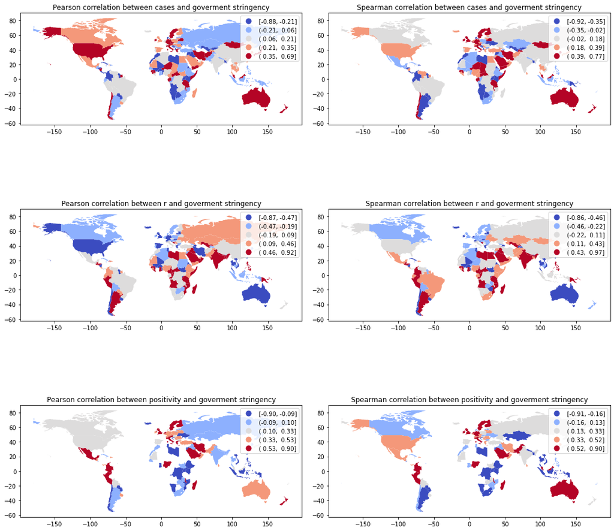

```python
ranks = ['Pearson', 'Spearman', 'Pearson', 'Spearman', 'Pearson', 'Spearman']
stats = ['cases', 'cases', 'r', 'r', 'positivity', 'positivity']
key = {'cases':data_cases, 'r':data_r, 'positivity':data_pos}

world = gpd.read_file(gpd.datasets.get_path('naturalearth_lowres'))
world.columns = ['pop_est', 'continent', 'name', 'iso_code', 'gdp_md_est', 'geometry']
location = pd.read_csv('https://raw.githubusercontent.com/melanieshi0120/COVID-19_global_time_series_panel_data/master/data/countries_latitude_longitude.csv')

f, axs = plt.subplots(3, 2, figsize=(15,15))

for rank, stat, i in zip(ranks, stats, range(1, 7)):
  merge = pd.merge(world, key[stat], on='iso_code')
  merge = merge.merge(location, on='name').sort_values(by='name').reset_index()

  plt.subplot(3, 2, i)
  merge.plot(column=rank, scheme="quantiles",
            legend=True,cmap='coolwarm', ax=plt.gca())
  plt.title(f'{rank} correlation between {stat} and goverment stringency')

plt.tight_layout()
plt.show()
```

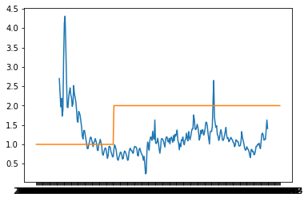

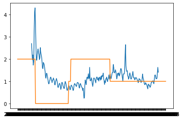

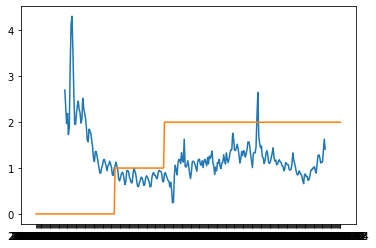

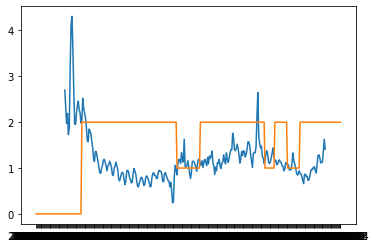

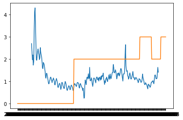

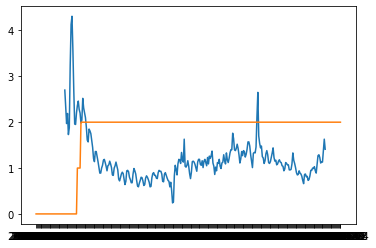

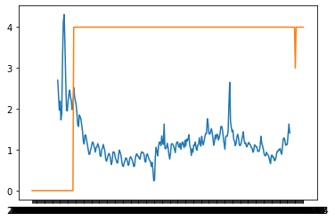

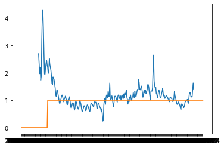

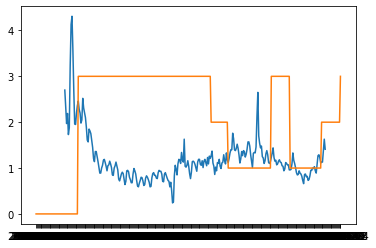

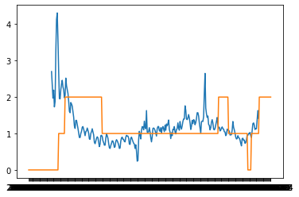

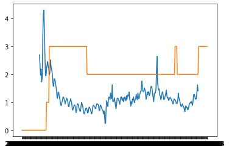

```python
files = [
         'covid-19-testing-policy.csv',
         'covid-contact-tracing.csv',
         'face-covering-policies-covid.csv',
         'internal-movement-covid.csv',
         'international-travel-covid.csv',
         'public-events-covid.csv',
         'public-gathering-rules-covid.csv',
         'public-transport-covid.csv',
         'school-closures-covid.csv',
         'stay-at-home-covid.csv',
         'workplace-closures-covid.csv'
]

measures = [
            'testing',
            'contact tracing',
            'face coverings',
            'internal movement restrictions',
            'international travel restrictions',
            'public event restrictions',
            'public gathering restrictions',
            'public transport restrictions',
            'school closures',
            'stay-at-home orders',
            'workplace closures'
]

covid_data = pd.read_csv("1_owid/owid-covid-data.csv")

for file, measure in zip(files, measures):
  meas_data = pd.read_csv(f"Stringency/owid_data/{file}")
  meas_data.columns = ['country', 'iso_code', 'date', 'measure']
  # countries_in = meas_data['iso_code'].unique()
  countries_in = ['GBR']

  for country in countries_in:
    cty_cov = covid_data.loc[covid_data['iso_code'] == country]
    cty_meas = meas_data.loc[meas_data['iso_code'] == country]
    country = cty_cov.merge(cty_meas, on='date')
    plt.plot(country['date'], country['reproduction_rate'])
    plt.plot(country['date'], country['measure'])
    plt.show()
```

```python
country
```

|  | iso_code_x | continent | location | date | total_cases | new_cases | new_cases_smoothed | total_deaths | new_deaths | new_deaths_smoothed | total_cases_per_million | new_cases_per_million | new_cases_smoothed_per_million | total_deaths_per_million | new_deaths_per_million | new_deaths_smoothed_per_million | reproduction_rate | icu_patients | icu_patients_per_million | hosp_patients | hosp_patients_per_million | weekly_icu_admissions | weekly_icu_admissions_per_million | weekly_hosp_admissions | weekly_hosp_admissions_per_million | new_tests | total_tests | total_tests_per_thousand | new_tests_per_thousand | … |
| --- | --- | --- | --- | --- | --- | --- | --- | --- | --- | --- | --- | --- | --- | --- | --- | --- | --- | --- | --- | --- | --- | --- | --- | --- | --- | --- | --- | --- | --- | --- |
| 0 | GBR | Europe | United Kingdom | 2020-01-31 | 2.0 | 2.0 | NaN | NaN | NaN | NaN | 0.029 | 0.029 | NaN | NaN | NaN | NaN | NaN | NaN | NaN | NaN | NaN | NaN | NaN | NaN | NaN | NaN | NaN | NaN | NaN | … |
| 1 | GBR | Europe | United Kingdom | 2020-02-01 | 2.0 | 0.0 | NaN | NaN | NaN | NaN | 0.029 | 0.000 | NaN | NaN | NaN | NaN | NaN | NaN | NaN | NaN | NaN | NaN | NaN | NaN | NaN | NaN | NaN | NaN | NaN | … |
| 2 | GBR | Europe | United Kingdom | 2020-02-02 | 2.0 | 0.0 | NaN | NaN | NaN | NaN | 0.029 | 0.000 | NaN | NaN | NaN | NaN | NaN | NaN | NaN | NaN | NaN | NaN | NaN | NaN | NaN | NaN | NaN | NaN | NaN | … |
| 3 | GBR | Europe | United Kingdom | 2020-02-03 | 8.0 | 6.0 | NaN | NaN | NaN | NaN | 0.118 | 0.088 | NaN | NaN | NaN | NaN | NaN | NaN | NaN | NaN | NaN | NaN | NaN | NaN | NaN | NaN | NaN | NaN | NaN | … |
| 4 | GBR | Europe | United Kingdom | 2020-02-04 | 8.0 | 0.0 | NaN | NaN | NaN | NaN | 0.118 | 0.000 | NaN | NaN | NaN | NaN | NaN | NaN | NaN | NaN | NaN | NaN | NaN | NaN | NaN | NaN | NaN | NaN | NaN | … |
| ... | ... | ... | ... | ... | ... | ... | ... | ... | ... | ... | ... | ... | ... | ... | ... | ... | ... | ... | ... | ... | ... | ... | ... | ... | ... | ... | ... | ... | ... | … |
| 335 | GBR | Europe | United Kingdom | 2020-12-31 | 2496231.0 | 56029.0 | 43012.429 | 73622.0 | 965.0 | 555.714 | 36770.923 | 825.339 | 633.598 | 1084.495 | 14.215 | 8.186 | NaN | NaN | NaN | NaN | NaN | NaN | NaN | NaN | NaN | NaN | NaN | NaN | NaN | … |
| 336 | GBR | Europe | United Kingdom | 2021-01-01 | 2549689.0 | 53458.0 | 45963.143 | 74237.0 | 615.0 | 562.143 | 37558.390 | 787.467 | 677.064 | 1093.554 | 9.059 | 8.281 | NaN | NaN | NaN | NaN | NaN | NaN | NaN | NaN | NaN | NaN | NaN | NaN | NaN | … |
| 337 | GBR | Europe | United Kingdom | 2021-01-02 | 2607542.0 | 57853.0 | 49258.143 | 74682.0 | 445.0 | 595.571 | 38410.598 | 852.208 | 725.601 | 1100.109 | 6.555 | 8.773 | NaN | NaN | NaN | NaN | NaN | NaN | NaN | NaN | NaN | NaN | NaN | NaN | NaN | … |
| 338 | GBR | Europe | United Kingdom | 2021-01-03 | 2662699.0 | 55157.0 | 52495.857 | 75137.0 | 455.0 | 611.000 | 39223.092 | 812.494 | 773.294 | 1106.811 | 6.702 | 9.000 | NaN | NaN | NaN | NaN | NaN | NaN | NaN | NaN | NaN | NaN | NaN | NaN | NaN | … |
| 339 | GBR | Europe | United Kingdom | 2021-01-04 | 2721622.0 | 58923.0 | 54990.571 | 75547.0 | 410.0 | 618.571 | 40091.062 | 867.970 | 810.043 | 1112.851 | 6.040 | 9.112 | NaN | NaN | NaN | NaN | NaN | NaN | NaN | NaN | NaN | NaN | NaN | NaN | NaN | … |

340 rows × 55 columns

```python
# just having a look at stringency & mobility

world = gpd.read_file(gpd.datasets.get_path('naturalearth_lowres'))
world.columns = ['pop_est', 'continent', 'name', 'iso_code', 'gdp_md_est', 'geometry']
location = pd.read_csv('https://raw.githubusercontent.com/melanieshi0120/COVID-19_global_time_series_panel_data/master/data/countries_latitude_longitude.csv')

common_countries = list(set(world.name.unique()).intersection(countries)) # list of countries to compare mobility & R
```

[output not shown]

```python
# some differences in country names - corrections
countries = ['Cambodia', 'Bosnia and Herzegovina', 'Pakistan', 'Honduras', 'Belgium', 'Iraq', 'Slovakia', 'El Salvador', 'Senegal', 'Finland', 'Luxembourg', 'Belarus', 'Tanzania', 'Kyrgyzstan', "Cote d'Ivoire", 'Bangladesh', 'Namibia', 'Austria', 'Mongolia', 'Kenya', 'Argentina', 'Belize', 'Jordan', 'Togo', 'Benin', 'Israel', 'Indonesia', 'Netherlands', 'Lithuania', 'Dominican Republic', 'Papua New Guinea', 'Switzerland', 'Rwanda', 'Poland', 'Jamaica', 'Portugal', 'Philippines', 'Slovenia', 'Uruguay', 'Barbados', 'Malta', 'Hong Kong', 'Germany', 'Libya', 'Ukraine', 'India', 'Mexico', 'Nigeria', 'Gabon', 'Singapore', 'Nepal', 'South Korea', 'New Zealand', 'Oman', 'Myanmar', 'Colombia', 'Paraguay', 'Panama', 'Burkina Faso', 'Moldova', 'Zambia', 'Estonia', 'Peru', 'Latvia', 'Mali', 'Bulgaria', 'France', 'Egypt', 'Norway', 'Vietnam', 'Chile', 'Tajikistan', 'Kazakhstan', 'United States', 'Ecuador', 'United Arab Emirates', 'Lebanon', 'Japan', 'Taiwan', 'United Kingdom', 'Thailand', 'Romania', 'Venezuela', 'Croatia', 'Trinidad and Tobago', 'Spain', 'South Africa', 'Uganda', 'Afghanistan', 'Turkey', 'Bahrain', 'Canada', 'Bolivia', 'Australia', 'Brazil', 'Fiji', 'Haiti', 'Ghana', 'Laos', 'Guatemala', 'Yemen', 'Costa Rica', 'Russia', 'Botswana', 'Sweden', 'Cape Verde', 'Greece', 'Kuwait', 'Zimbabwe', 'Qatar', 'Nicaragua', 'Czechia', 'Mozambique', 'Angola', 'Ireland', 'Hungary', 'Sri Lanka', 'Cameroon', 'Morocco', 'Italy', 'Niger', 'Malaysia', 'Serbia', 'Mauritius', 'Denmark', 'Georgia', 'Saudi Arabia']
countries_old = countries
country_spear = [0.695540005173686, 0.7448660212830175, 0.7114473627201232, 0.8495509449888616, 0.9082783081519682, 0.8955589921491717, 0.8855554924068987, 0.8708077941286194, 0.8234185711332379, 0.8461160046826116, 0.7689611220138082, 0.3043217586359732, 0.3824335179030222, 0.3461487123244059, 0.5306274537116933, 0.45922865703983273, 0.896570924962455, 0.8971232415405479, 0.46647972566383344, 0.9462575837407246, 0.9421825304693274, 0.5119690857722862, 0.8662193326892287, 0.6311861706718643, 0.6874337994640094, 0.7564544460566226, 0.6362557010456416, 0.9149660323398158, 0.8678421756107019, 0.9156577358413205, 0.2670889642260143, 0.8014891531263009, 0.44168105647575123, 0.8438946706219779, 0.6029310583646665, 0.8608211102022915, 0.8288671897735225, 0.7621054978336618, 0.5590875541305136, 0.8082741785653518, 0.8813109135590337, 0.7126520577695067, 0.8600491095210677, 0.5576229134188648, 0.6714542987553086, 0.7914819546321499, 0.5670849733721303, 0.7406471345178687, 0.8058108163014788, 0.570441479942716, 0.8733968504460053, 0.47899557416050054, 0.8448576542728756, 0.7803466427079628, 0.3070351781716455, 0.8798187364498409, 0.9170395858123922, 0.7813602449656507, 0.6934012419249587, 0.9307313994186238, 0.2631984943515093, 0.7847945588085199, 0.857486744001721, 0.7631150097484914, 0.8635643379655166, 0.8544422927616621, 0.9029089617334608, 0.6737943895290158, 0.868346898398928, 0.6241794183721672, 0.2651383870629622, -0.11576905600182226, 0.6267903074491296, 0.9097145718657433, 0.8962324449480341, 0.702007098492927, 0.6240151859988833, 0.06373406867534304, 0.6312499019095256, 0.8097071160239881, 0.826917012233815, 0.8618999585904378, -0.25609723808524903, 0.6464085576450177, 0.633167152402715, 0.82946618381801, 0.8715088113404149, 0.5768440989185775, 0.6364234251599734, 0.6879314487726969, 0.9063452415515744, 0.7415819207654992, 0.5289239142841309, 0.6590762644701269, 0.8538909453935496, 0.7797041543358633, 0.7590856707220158, 0.7542581743617296, 0.4523675567228554, 0.8928356516331377, 0.629082045391055, 0.9082709501748083, 0.4297006469226176, 0.6219330626687919, 0.6471200794537659, -0.17405852792449136, 0.7665584457647711, 0.929845568426869, 0.8251671427054067, 0.9020191922978914, 0.6913670413579537, 0.8686826600835643, 0.16597933713292876, 0.7459219462283398, 0.7480779421671535, 0.8270145810230358, 0.8242204919920885, 0.7750548159921042, 0.785178669868894, 0.8097128917771965, 0.5587232907286744, 0.7923380082446184, 0.7976612612884046, 0.8198157548732729, 0.5921438608234859, 0.786512082875846, 0.9412842493256436]

# country_spear is a list of spearman correlation (mobility vs stringency) corresponding to the list of countries (calculated in another notebook)

countries = [c.replace('Bosnia and Herzegovina', 'Bosnia and Herz.') for c in countries]
countries = [c.replace("Cote d'Ivoire", "Côte d'Ivoire") for c in countries]
countries = [c.replace('Dominican Republic', 'Dominican Rep.') for c in countries]
countries = [c.replace('United States', 'United States of America') for c in countries]

# remove missing countries & spearman values
to_remove = ['Bahrain','Barbados','Cape Verde','Hong Kong','Malta','Mauritius','Singapore']
rem_ind = []
for i in range(len(countries)):
  if countries[i] in to_remove:
    rem_ind+=[i]
for j in sorted(rem_ind, reverse=True):
  del countries[j]
  del country_spear[j]

df_country = pd.DataFrame({'country':countries, 'spearman':country_spear})
```

```python
merge = pd.merge(world, df_country, on='name')
merge = merge.merge(location, on='name').sort_values(by='name').reset_index()

f, axs = plt.subplots(1, 1, figsize=(10,6))

merge.plot(column='spearman', scheme="quantiles",
          legend=True,cmap='coolwarm', ax=plt.gca())
plt.title('Spearman correlation between mobility and goverment stringency')

plt.tight_layout()
plt.show()
```

[output not shown]

Time-lagged cross correlations  
Should help indicate some amount of causality  
Starting with the UK (doing for all countries might be tricky!)

```python
  uk = df.loc[df['iso_code'] == 'GBR']
  uk
```

|  | iso_code | continent | location | date | total_cases | new_cases | new_cases_smoothed | total_deaths | new_deaths | new_deaths_smoothed | total_cases_per_million | new_cases_per_million | new_cases_smoothed_per_million | total_deaths_per_million | new_deaths_per_million | new_deaths_smoothed_per_million | reproduction_rate | icu_patients | icu_patients_per_million | hosp_patients | hosp_patients_per_million | weekly_icu_admissions | weekly_icu_admissions_per_million | weekly_hosp_admissions | weekly_hosp_admissions_per_million | new_tests | total_tests | total_tests_per_thousand | new_tests_per_thousand | … |
| --- | --- | --- | --- | --- | --- | --- | --- | --- | --- | --- | --- | --- | --- | --- | --- | --- | --- | --- | --- | --- | --- | --- | --- | --- | --- | --- | --- | --- | --- | --- |
| 54677 | GBR | Europe | United Kingdom | 2020-01-31 | 2.0 | 2.0 | NaN | NaN | NaN | NaN | 0.029 | 0.029 | NaN | NaN | NaN | NaN | NaN | NaN | NaN | NaN | NaN | NaN | NaN | NaN | NaN | NaN | NaN | NaN | NaN | … |
| 54678 | GBR | Europe | United Kingdom | 2020-02-01 | 2.0 | 0.0 | NaN | NaN | NaN | NaN | 0.029 | 0.000 | NaN | NaN | NaN | NaN | NaN | NaN | NaN | NaN | NaN | NaN | NaN | NaN | NaN | NaN | NaN | NaN | NaN | … |
| 54679 | GBR | Europe | United Kingdom | 2020-02-02 | 2.0 | 0.0 | NaN | NaN | NaN | NaN | 0.029 | 0.000 | NaN | NaN | NaN | NaN | NaN | NaN | NaN | NaN | NaN | NaN | NaN | NaN | NaN | NaN | NaN | NaN | NaN | … |
| 54680 | GBR | Europe | United Kingdom | 2020-02-03 | 8.0 | 6.0 | NaN | NaN | NaN | NaN | 0.118 | 0.088 | NaN | NaN | NaN | NaN | NaN | NaN | NaN | NaN | NaN | NaN | NaN | NaN | NaN | NaN | NaN | NaN | NaN | … |
| 54681 | GBR | Europe | United Kingdom | 2020-02-04 | 8.0 | 0.0 | NaN | NaN | NaN | NaN | 0.118 | 0.000 | NaN | NaN | NaN | NaN | NaN | NaN | NaN | NaN | NaN | NaN | NaN | NaN | NaN | NaN | NaN | NaN | NaN | … |
| ... | ... | ... | ... | ... | ... | ... | ... | ... | ... | ... | ... | ... | ... | ... | ... | ... | ... | ... | ... | ... | ... | ... | ... | ... | ... | ... | ... | ... | ... | … |
| 55012 | GBR | Europe | United Kingdom | 2020-12-31 | 2496231.0 | 56029.0 | 43012.429 | 73622.0 | 965.0 | 555.714 | 36770.923 | 825.339 | 633.598 | 1084.495 | 14.215 | 8.186 | NaN | NaN | NaN | NaN | NaN | NaN | NaN | NaN | NaN | NaN | NaN | NaN | NaN | … |
| 55013 | GBR | Europe | United Kingdom | 2021-01-01 | 2549689.0 | 53458.0 | 45963.143 | 74237.0 | 615.0 | 562.143 | 37558.390 | 787.467 | 677.064 | 1093.554 | 9.059 | 8.281 | NaN | NaN | NaN | NaN | NaN | NaN | NaN | NaN | NaN | NaN | NaN | NaN | NaN | … |
| 55014 | GBR | Europe | United Kingdom | 2021-01-02 | 2607542.0 | 57853.0 | 49258.143 | 74682.0 | 445.0 | 595.571 | 38410.598 | 852.208 | 725.601 | 1100.109 | 6.555 | 8.773 | NaN | NaN | NaN | NaN | NaN | NaN | NaN | NaN | NaN | NaN | NaN | NaN | NaN | … |
| 55015 | GBR | Europe | United Kingdom | 2021-01-03 | 2662699.0 | 55157.0 | 52495.857 | 75137.0 | 455.0 | 611.000 | 39223.092 | 812.494 | 773.294 | 1106.811 | 6.702 | 9.000 | NaN | NaN | NaN | NaN | NaN | NaN | NaN | NaN | NaN | NaN | NaN | NaN | NaN | … |
| 55016 | GBR | Europe | United Kingdom | 2021-01-04 | 2721622.0 | 58923.0 | 54990.571 | 75547.0 | 410.0 | 618.571 | 40091.062 | 867.970 | 810.043 | 1112.851 | 6.040 | 9.112 | NaN | NaN | NaN | NaN | NaN | NaN | NaN | NaN | NaN | NaN | NaN | NaN | NaN | … |

340 rows × 52 columns

```python
run('r', ["GBR"])
```

|  | iso_code | Pearson | Spearman |
| --- | --- | --- | --- |
| 0 | GBR | -0.668588 | -0.394619 |

```python
def lag_corr(x, y, lag):
  return x.corr(y.shift(lag))
```

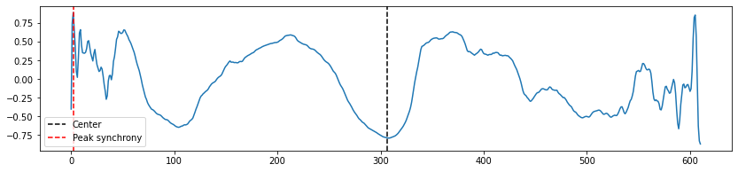

```python
d1 = uk['stringency_index']
d2 = uk['reproduction_rate']
x = pd.to_datetime(uk['date'])
xx = mdates.date2num(x)  # for fitting
rs = [lag_corr(d1,d2, lag) for lag in range(-len(xx), len(xx))]
rs = np.array(rs)
rs = rs[~np.isnan(rs)]
f,ax=plt.subplots(figsize=(14,3))
ax.plot(rs)
ax.axvline(np.ceil(len(rs)/2),color='k',linestyle='--',label='Center')
ax.axvline(np.argmax(rs),color='r',linestyle='--',label='Peak synchrony')
plt.legend()
plt.show()
```

```python
len(rs)
```

```
611
```

```
y2 is -170.0 behind y1
```

[figure not shown]

```python
from scipy import signal

def lag_finder(y1, y2, sr):
    n = len(y1)

    corr = signal.correlate(y2, y1, mode='same') / np.sqrt(signal.correlate(y1, y1, mode='same')[int(n/2)] * signal.correlate(y2, y2, mode='same')[int(n/2)])

    delay_arr = np.linspace(-0.5*n/sr, 0.5*n/sr, n)
    delay = delay_arr[np.argmax(corr)]
    print('y2 is ' + str(delay) + ' behind y1')

    plt.figure()
    plt.plot(delay_arr, corr)
    plt.title('Lag: ' + str(np.round(delay, 3)) + ' s')
    plt.xlabel('Lag')
    plt.ylabel('Correlation coeff')
    plt.show()

lag_finder(d1, d2, 1)
```

Simply plotting R against stringency for each country, then fitting a straight line? Expect a negative gradient - stronger gradient = greater compliance?

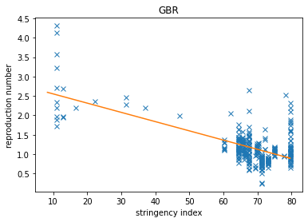

```
GBR -0.023837488382810357
```

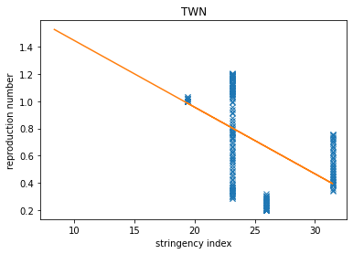

```
TWN -0.04896296374705277
```

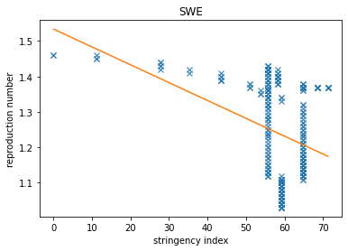

```
SWE -0.005035610813657328
```

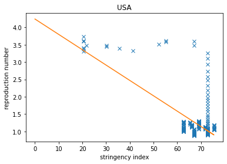

```
USA -0.044221180597027065
```

```python
countries = ['GBR', 'TWN', 'SWE', 'USA']

for country in countries:
  cty = df.loc[df['iso_code'] == country]

  d1 = cty['stringency_index']
  d2 = cty['reproduction_rate']

  plt.plot(d1, d2, 'x')
  plt.xlabel('stringency index')
  plt.ylabel('reproduction number')
  plt.title(country)

  # SPLIT = 100
  nas = np.logical_or(np.isnan(d1), np.isnan(d2))
  c, m = poly.polyfit(d1[~nas], d2[~nas], 1)
  plt.plot(d1, (m * d1) + c, '-')
  plt.show()
  print(country, m)
```

How about mean R vs mean stringency for all countries?

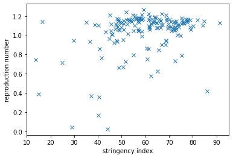

```python
countries = df['iso_code'].unique()

rs, stringencies = [], []

for country in countries:
  cty = df.loc[df['iso_code'] == country]

  d1 = cty['stringency_index']
  d2 = cty['reproduction_rate']

  rs.append(d1.mean())
  stringencies.append(d2.mean())

plt.plot(rs, stringencies, 'x')
plt.xlabel('stringency index')
plt.ylabel('reproduction number')

  # SPLIT = 100
  # nas = np.logical_or(np.isnan(d1), np.isnan(d2))
# c, m = poly.polyfit(d1[~nas], d2[~nas], 1)
# plt.plot(d1, (m * d1) + c, '-')
# plt.show()
# print(m)
```

Probably need to look at things after a certain date... cutting off the first bit of the data

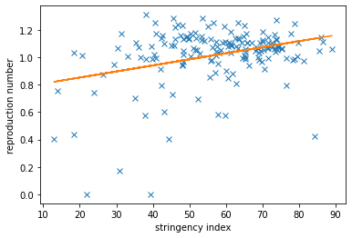

```
0.004421123961248445
```

```python
countries = df['iso_code'].unique()

rs, stringencies = [], []

CUT = 100

for country in countries:
  cty = df.loc[df['iso_code'] == country]

  d1 = cty['stringency_index']
  d2 = cty['reproduction_rate']

  rs.append(d1[CUT:].mean())
  stringencies.append(d2[CUT:].mean())

plt.plot(rs, stringencies, 'x')
plt.xlabel('stringency index')
plt.ylabel('reproduction number')

d1 = np.array(rs)
d2 = np.array(stringencies)

SPLIT = 0
nas = np.logical_or(np.isnan(d1), np.isnan(d2))
c, m = poly.polyfit(d1[~nas][SPLIT:], d2[~nas][SPLIT:], 1)
plt.plot(d1[SPLIT:], (m * d1[SPLIT:]) + c, '-')
plt.show()
print(m)
```

Nope, this is no good.  
Let's do a heatmap of the above gradients.

```python
countries = df['iso_code'].unique()

countries_out, gradients = [], []

for country in countries:
  try:
    cty = df.loc[df['iso_code'] == country]

    d1 = cty['stringency_index']
    d2 = cty['reproduction_rate']

    # plt.plot(d1, d2, 'x')
    # plt.xlabel('stringency index')
    # plt.ylabel('reproduction number')
    # plt.title(country)

    SPLIT = 100
    nas = np.logical_or(np.isnan(d1), np.isnan(d2))
    c, m = poly.polyfit(d1[~nas][SPLIT:], d2[~nas][SPLIT:], 1)
    countries_out.append(country)
    gradients.append(m)
    # plt.plot(d1, (m * d1) + c, '-')
    # plt.show()
    # print(country, m)
  except TypeError:
    continue

out = pd.DataFrame(list(zip(countries_out, gradients)),
                  columns =['iso_code', 'gradient'])

out
```

|  | iso_code | gradient |
| --- | --- | --- |
| 0 | AFG | -0.005817 |
| 1 | ALB | -0.000434 |
| 2 | DZA | -0.026955 |
| 3 | AND | 0.001475 |
| 4 | AGO | 0.005544 |
| ... | ... | ... |
| 160 | VEN | 0.010733 |
| 161 | VNM | -0.008797 |
| 162 | YEM | -0.025019 |
| 163 | ZMB | -0.004140 |
| 164 | ZWE | -0.016703 |

165 rows × 2 columns

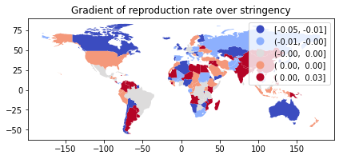

```python
world = gpd.read_file(gpd.datasets.get_path('naturalearth_lowres'))
world.columns = ['pop_est', 'continent', 'name', 'iso_code', 'gdp_md_est', 'geometry']
location = pd.read_csv('https://raw.githubusercontent.com/melanieshi0120/COVID-19_global_time_series_panel_data/master/data/countries_latitude_longitude.csv')


merge = pd.merge(world, out, on='iso_code')
merge = merge.merge(location, on='name').sort_values(by='name').reset_index()

merge.plot(column='gradient', scheme="quantiles",
          legend=True,cmap='coolwarm', ax=plt.gca(), figsize=(20, 20))
plt.title('Gradient of reproduction rate over stringency')

plt.tight_layout()
plt.show()
```